# Lab meeting Garant

15 mars 2018

## Quoi faire avec des données répétées?

- Modèles mixtes
- Choisir une seule valeur aléatoirement
- Utiliser la moyenne/médiane

## Valeur aléatoire ou moyenne?

Parfois la réponse est évidente:

- 2 génotypes pour un même individu

D’autres fois, moins:

- Longueur du tarse chez l’hirondelle
- MDA chez les tamias

**La réponse dépend probablement à la fois de la nature de la variation intra-sujet, du nombre de répétitions par sujet et du type de question qui est posé…**

## Ce que je pensais, mais sans référence (!)

**Utiliser la moyenne réduit la variance observée dans les données, donc mieux vaut utiliser une valeur aléatoire.**

Est-ce vrai?

```r
# Population composée  de N individus,
N.ID     <- 100

#avec un trait X distribué normalement, ayant une moyenne + SD
POP.MEAN <- 500
POP.SD   <- 100

# Le trait est mesuré plusieurs fois par individu, avec un SD intra-individu
N.REP <- c(2,10)
ID.SD <- c(5,50)
```

## Utiliser la moyenne réduit la variance?

On crée un jeu de donnée pour chacune des conditions:

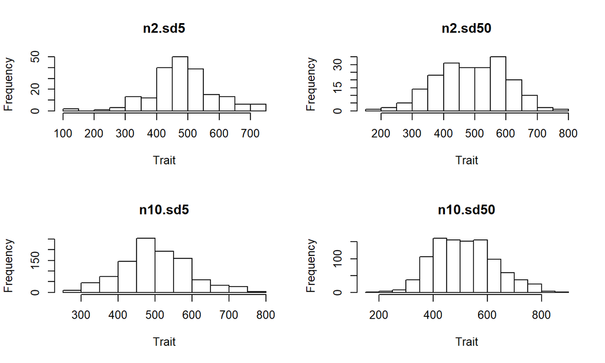

## Utiliser la moyenne réduit la variance?

On crée un jeu de donnée pour chacune des conditions, desquels on peut calculer certaines statistiques:

| Data | Vreal | Vrandom | Vmean |
| --- | --- | --- | --- |
| n2.sd5 | 10352 | 10356 | 10385 |
| n2.sd50 | 10546 | 13768 | 11160 |
| n10.sd5 | 8015 | 7985 | 8029 |
| n10.sd50 | 10325 | 11419 | 10578 |

## Utiliser la moyenne réduit la variance?

Puis on refait la même opération **1000 fois** pour faire des statistiques sur des distributions de variance!!

|  | Vreal | Vrandom | Vmean |
| --- | --- | --- | --- |
|  | Min. : 5616 | Min. : 6289 | Min. : 6389 |
|  | 1st Qu.: 8967 | 1st Qu.: 9696 | 1st Qu.: 9229 |
|  | Median : 9906 | Median :11070 | Median :10232 |
|  | Mean : 9957 | Mean :11219 | Mean :10337 |
|  | 3rd Qu.:10866 | 3rd Qu.:12614 | 3rd Qu.:11334 |
|  | Max. :15497 | Max. :19069 | Max. :17213 |

## Utiliser la moyenne réduit la variance?

Est-ce que le N.REP et le ID.SD influencent la variance?

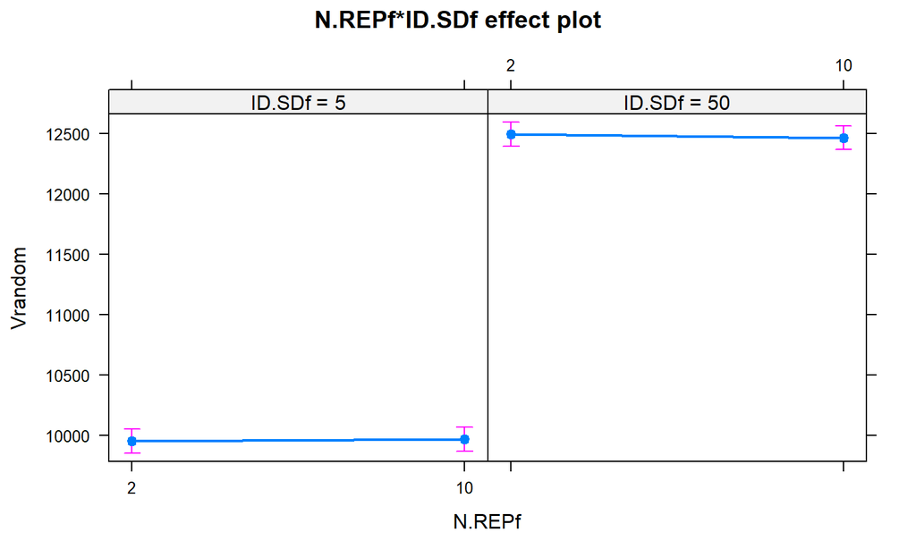

```r
m1 <- lm(Vrandom ~ N.REPf*ID.SDf, data=RES2)
plot(allEffects(m1))
```

## Utiliser la moyenne réduit la variance?

Est-ce que le N.REP et le ID.SD influencent la variance?

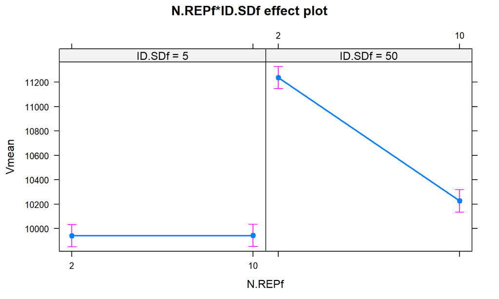

```r
m2 <- lm(Vmean ~ N.REPf*ID.SDf, data=RES2)
plot(allEffects(m2))
```

## Utiliser la moyenne réduit la variance?

Est-ce qu’il y a des différences entre Vreal, Vmean et Vrandom?

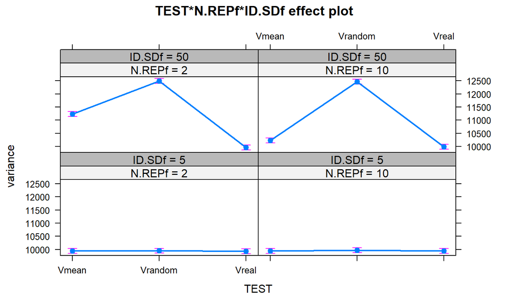

```r
m3 <- lm(variance ~ TEST*N.REPf*ID.SDf, data=RES3)
plot(allEffects(m3))
```

## Utiliser la moyenne réduit la variance?

Donc, oui, sous certaine condition. Mais est-ce vraiment important?

**La réponse (moyenne vs aléatoire) dépend probablement à la fois de la nature de la variation intra-sujet, du nombre de répétitions par sujet et du type de question qui est posé…**

**Steel, E. A., Kennedy, M. C., Cunningham, P. G., & Stanovick, J. S. (2013). Applied statistics in ecology: common pitfalls and simple solutions. Ecosphere, 4(9), art115.**

- Pitfall #2 : Arbitrary thresholds, metrics, and indicators